# EDA: Importaciones en Colombia pre, durante y post pandemia de Covid-19

2024-12-7

**REALIZACIÓN A:**

- Estadística I
- Universidad Industrial de Santander
- Profesor: Hoover R. Chacón
- Ingeniería de Sistemas
- **Participantes:**
  - Angela Lozano
  - Jose Quintero
  - Nicolas Quinter

### **1. Introducción**

- **1.1.** Planteamiento

Donde nuestras diversas hipótesis son: ¿La pandemia en realidad afecto las imprtaciones? ¿que tan significativa fué?

- **1.2.** Abordamiento

Abordamos el problema desde el análisis y comprensión de los datos que estabamos manejando, entender qué significaban sus siglas, que tipos de datos teníamos para trabajar y posteriormente como podíamos presentarlos de modo que reflejarán la situación del contexto.

La metodología se basó en organizar que tipo de gráficas queríamos llegar a obtener, los cálculos que podríamos lograr con los datos que teníamos y su relevancia para el contexto. Así sucesivamente fuimos revisando la teoría vista en clase porque nuestra misión es aplicar lo visto en el curso, por lo qué a medida de que vamos avanzando esperamos obtener más ideas de datos relevantes a analizar.

Por otro lado la creación de estos gráficos y cálculos, se basó en entrar primero al csv original desde una vista de excel e ir identificando que tan limpios estaban los datos y ver que datos debiamos filtrar, cambiar o transdormar (de carcatéres a numéricos) si era necesario. El proceso se repetía en cada objetivo que teníamos.

- **1.3.** Enfoque/técnica analítica

Actualmente nuestra analitica se basa en tener gráficas que nos ayuden a mostrar cómo se comportaron las importaciones durante los años de pandemia. Iniciamos con los datos más básicos que nos brinda la base y seguido de esto esperamos sacar probabilidades y conjeturas de cuales fueron los departamentos donde hubo una mayor reducción de las actividades.

- **1.4.** Beneficios al consumidor

Esperamos que nuestro análisis ayude al consumidor a ver como las mercancias se comportan en una época de crisis, en qué ciudades receptoras se incrementaron los aranceles y por ende se incrementaron los precios y cuales fueron esos puntos de quiebre que hicieron que los precios se dispararon para poder tener un mejr maneja sobre importaciones en futuras crisis.

### **2. Preparación de los datos**

- **2.1.** Obtecnión original de los datos

La base de datos utilizada durante el estudio fue obtenida a través de los recursos virtuales del DANE, la cual proporciona datos publicos en su servicio de *(ANDA)*, donde nos enontramos con un catálogo de nichos de los cuales se proporcionaban archivos de extension “.CSV” con datos de interés; entre las categorías nos inclinamos por la colección de economia-microdatos, por el nicho de economía internacional, donde entre la lista de opciones de censos nos cautivo las *Estadísticas de Importaciones - IMPO - 2012 A 2024* (https://microdatos.dane.gov.co/index.php/catalog/473/get-microdata).

- **2.2.** Explicación de datos originales

Los datos fueron recolectados por el D.A.N.E para garantizar la veracidad y transparencia de la información básica y estratégica para la investigación y los usuarios relacionados con las compras al exterior. Los microdatos registran las importaciones de mercancías legales desde otros países o desde una región portuaria de Colombia al resto del territorio aduanero nacional. Los datos se basan en las en la fecha de presentación.

Los datos se almacenan en una base de datos proporcionada por ANDA, que cuenta con 44 variables, 20 discretas y 24 continuas. Los datos carecen de clasificación *específica* de las mercancías, lo más cercano es la empresa que recibe la mercancia, para la cantidad de variables se proporciona un diccionario de dato donde los nombres de las variables son acrónimos de su significado sencillos de interpretar.

Algo que también nos parecio curioso es que hay dos variables llamadas Pais de Procedencia (PAISPRO) y Pais de Compra (PAISCOM) que, en algunos casos, son iguales pero en la mayoría de casos es diferente lo que hace pensar que muchas mercancías son hechas en un país (PAISPRO) y son vendidas desde otros pais (PAISCOM), nos parecio curioso.

| Variable | Descripción | Variable | Descripción |
| --- | --- | --- | --- |
| FECH | Fecha de proceso | CUIDAIMP | Ciudad del importador |
| ADUA | Código de la aduana | CUIDAEXP | Ciudad del exportador |
| PAISGEN | País origen | ACTECON | Actividad económica |
| PAISPRO | País de procedencia | CODADAD | Código administración de aduana |
| PAISCOM | País de compra | VADUA | Valor aduana |
| DEPTODES | Departamento destino | VRAJUS | Valor ajuste |
| VIATRANS | Código vía de transporte | BASEIVA | Base IVA |
| BANDERA | Bandera | OTROSP | Porcentaje otros |
| REGIMEN | Código de régimen | OTROSBASE | Base otros |
| ACUERDO | Código del acuerdo | TOTALIVAYO | Total IVA y otros gastos |
| PBK | Peso bruto en kilos | SEGUROS | Seguros |
| PNK | Peso neto en kilos | OTROSG | Otros gastos |
| CANU | Cantidad de unidades | LUIN | Lugar de ingreso |
| CODA | Código de unidad | CODLUIN | Código lugar de ingreso |
| NABAN | Posición arancelaria | DEPIM | Departamento del importador |
| VAFODO | Valor FOB dólares de la mercancía | COPAEX | Código país del exportador |
| FLETE | Fletes | TIPOIM | Tipo de importación |
| VACID | Valor CIF dólares de la mercancía | PORARA | Porcentaje de arancel |
| VACIP | Valor CIF pesos de la mercancía | NIT | Número de identificación Tributaria |
| IMP1 | Impuesto a las ventas | DIGV | Dígito de Verificación |
| OTDER | Otros Derechos | RZIMPO | Razón social del importador |
| CLASE | Clase de importador | DEREL | Derechos Arancelarios |

- **2.5.** Información resumida:

En la obtención de los datos, se puede ver que promedio de los datos de 2019 y 2020 no hubo tanta variación, en promedio, sin embargo, se puede observar que existieron aduanas donde su cobro máximo alcanzó el valor más alto de los 4 años, reflejando que este costo se llegó a incrementar abismalmente por las medidas de bioseguridad implementadas.

### **3.Metodología**

El primer paso de la limpieza fue ir descargando los archivos “.zip” de año a través del sitio elegido para obtención de datos (DANE), para extraer los “.csv” de cada mes del año correspondiente gracias a que los archivos están muy bien categorizados, nos ahorro algo de tiempo. Seguimos importando y extrayendo los datos necesarios a través de R, donde debimos hacer lectura de “.csv” aclarando que el primer año esta separado por “;” y los demás años por “,”, este proceso lo hicimos a través de la definción de una ruta base, lo que agiliza el codigo, que es la carpeta principal donde se guardaron todas las importaciones de los 4 años, en nuestra carpeta de drive vera una careta por cada año, lo ideal es que estas cuatros carpetar sean guardadas en una carpeta especifica cuya ruta será la ruta base. **Tener en cuenta que RStudio no le los carctaeres de la ruta base como “/” deben cmabiarse por “\".**

Y desde su computador o dispositivo tendrá que captar la ruta de esta carpeta dónde haya destinado guardarla y colocarla como guía en la ruta base haciendo el cambio respectivo en la ruta base y, no olvidarlo, **cambiar los carcteres “/” por “\” para una lectura correcta de los archivos.**

Esto permite la extracción hacia R de todos los datos de los “.CSV” al entorno de desarrollo. Una vez hicimos este proceso, continuamos limpiando los data frames originales con las columnas de los datos de interes (PBK, FLETES, VACID, VADUA, “VAFODO”, entre otras posibles), obteniendo los “.CSV” limpios con las columnas necesarias a analizar.

Se aplico una función de limpieza de columnas donde se convertian los datos en tipo”carcater” o “numeric” tal fuera necesaio para el análisis, además de eliminar espacios en blanco o datos vacios (NA), tambiés se onvirtieron los carctaeres de tipo “,” a tipo “.” para su procesaiento con las funciones de R.

El paso a continuación fue crear un data frame de cada año (tablas_año) donde guardamos las columnas de cda mes en una comluna mayor de su mes correspondiente, esto nos permitio tener un data frame general para cada año y dandonos acceso rápido a cada los meses correspondientes.

Extracción de columnas de interes especifico con el fin de aligerar el peso de los data frame anteriores y a su vez filtrar por datos relevantes para este proyecto

# **4. Resultados**

- Aduanas

Podemos ver que el valor de las aduanas que es regulado por la DIAN en nuestro país y que se ve afectado por varios factores como acuerdos internacionales y los que más queremos resaltar que fueron los directamente afectados por la pandemia: el precio de compra de las mercancías y gastos relacionados con la carga, descarga y manipulación de las mercancías en el puerto o lugar de importación.

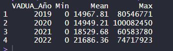

- Frecuencias

  En las siguientes graficas se puede observar el numero de importaciones que se realizaron todos los meses de los años 2019 al 2022.En el grafico del año 2020 se puede observar como la cantidad de importaciones disminuyo drasticamente los meses de Abril, Mayo y Junio, que es cercano a cuando se declaro pandemia en el pais (12 de marzo, 2020), de igual modo se puede observar como eventualmente el número de importaciones empieza a aumentar hasta volver a la normalidad como se puede observar en la ultima grafica con el promedio de importaciones mensuales de cada año, en el que en el año 2020 cayo casi 60000 puntos y al año siguiente aumento hasta que en el 2022 se volvio (y se superó) la cifra del año 2019.

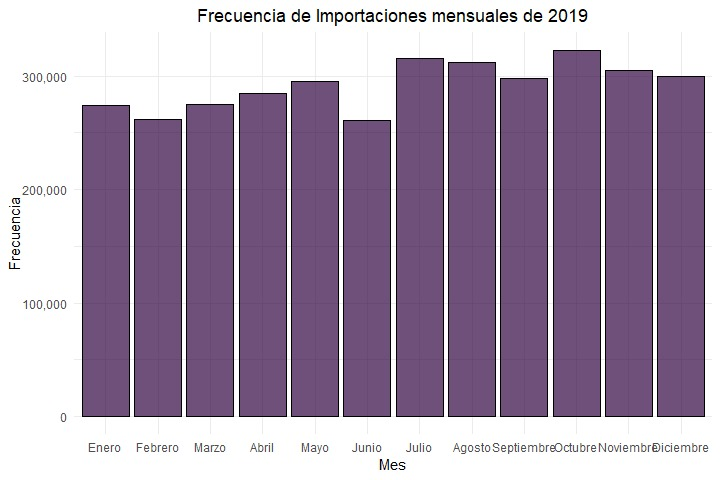

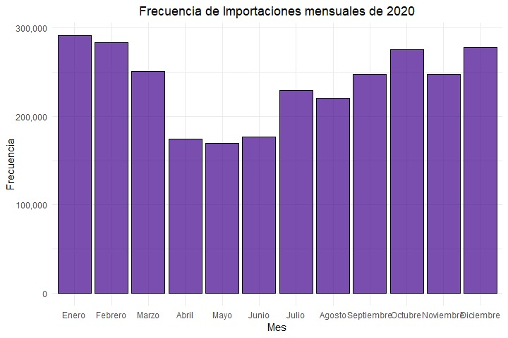

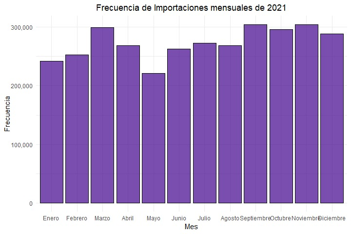

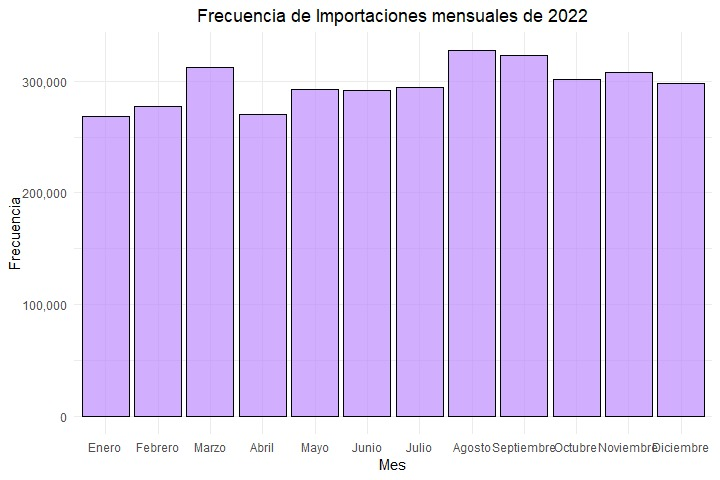

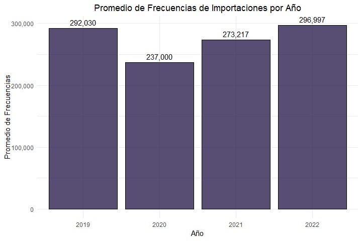

- Valor importado

En la grafica se puede observar lo que se mencionaba anteriormente, como la actividad de importación desde el exterior vivio un momento de recesión por el momento historico que se vivio (la pandemia por COVID-19) y como esta actividad se recupera poco a poco. Esto destaca la resilencia del comercio internacional despues de haber pasado por un evento disruptivo.

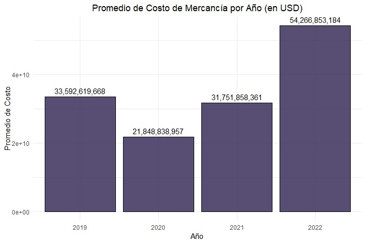

- Flete

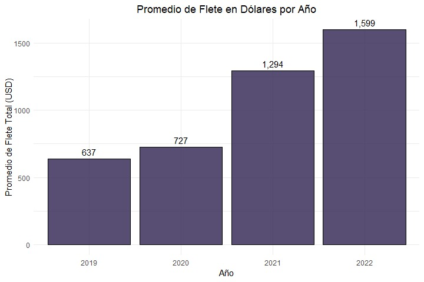

- Tipo de transporte

1 MARITIMO

2 FERREO

3 TERRESTRE

4 AEREO

5 CORREO

6 MULTIMODAL

7 INSTALACIONES DE TRANSPORTE FIJAS (TUBERIAS, CABLE, ETC.)

8 VIAS NAVEGABLES INTERIORES

9 OTRO MODO DE TRANSPORTE

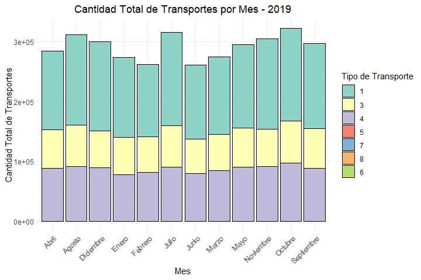

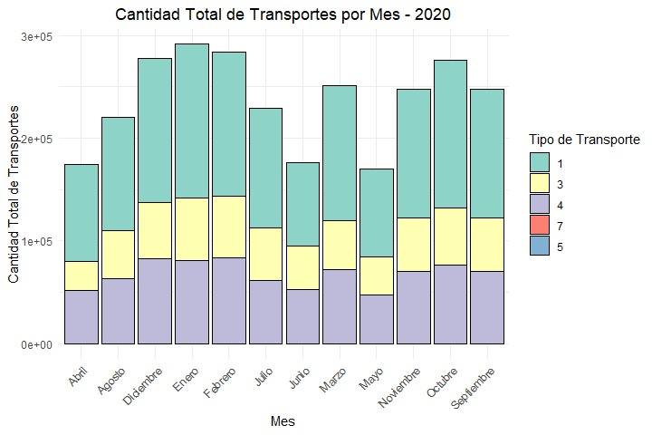

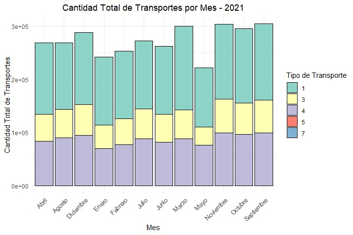

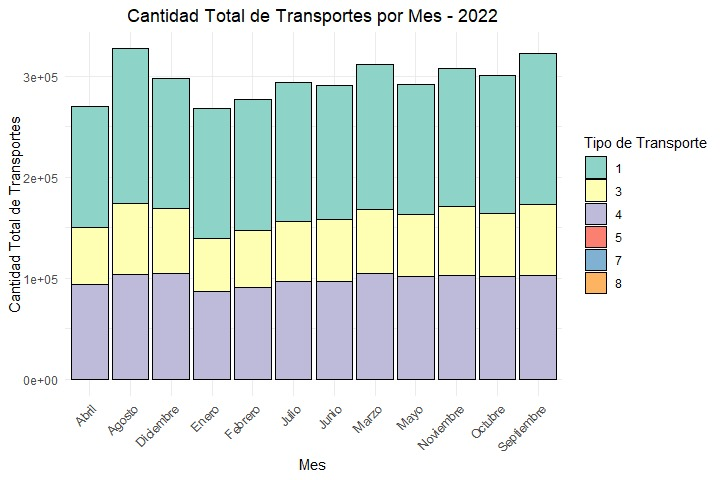

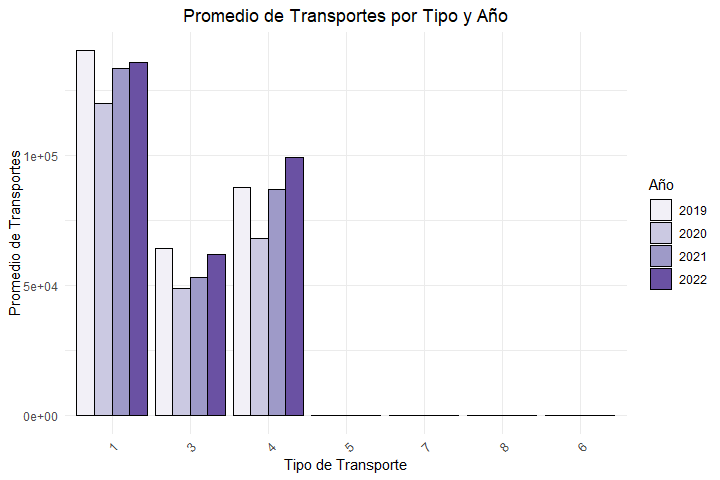

# **5. Conclusiones**

Por otro lado, debemos mencionar que ell costo de los fletes que es el costo total del valor del transporte de cada mercancia era bastante bajo en 2019 yy tuve un crecimiento leve en 2020 pero se fue al alza con rapidez en 2021-2022, la conjetura del motivo son las implentaciones de medidas de bioseguridad y revisión de las cargas por parte de entidades de salubridad para el manejo y discipación del virus.